# BIOSTAT 203B Homework 3

Due Friday, 2/28 @ 11:59 PM

Tony Lim

## Task

1. Develop a Shiny app that visualizes the progression of the 2019-20 Global Coronavirus Outbreak.
2. If you are ambitious, bring in visualization of other types of data, e.g., stock market, tweets, contrast with previous outbreak (e.g., 2003 SARS, 2009 H1N1, 2012 MERS, 2014 Ebola), prediction from your statistical/epidemiological model, and so on.
3. Publish your Shiny app to https://www.shinyapps.io and share the link.
4. (Optinal) Submit your app to the 2020 Shiny Contest (deadline 20 March 2020 at 5pm ET).

Below is some data exploration, which may help you get started. You do *not* have to use it. Note below code may change frequently.

## Import JHU SSE data on GitHub into R

Since Feb 11, JHU SSE is hosting 2019 nCoV data on GitHub repo: https://github.com/CSSEGISandData/2019-nCoV.

Let’s import the time series data directly from the csv file on GitHub:

```r
(confirmed <- read_csv("https://raw.githubusercontent.com/CSSEGISandData/COVID-19/master/csse_covid_19_data/csse_covid_19_time_series/time_series_19-covid-Confirmed.csv"))
```

```
## # A tibble: 76 x 34
##    `Province/State` `Country/Region`   Lat  Long `1/22/20` `1/23/20` `1/24/20`
##    <chr>            <chr>            <dbl> <dbl>     <dbl>     <dbl>     <dbl>
##  1 Anhui            Mainland China    31.8  117.         1         9        15
##  2 Beijing          Mainland China    40.2  116.        14        22        36
##  3 Chongqing        Mainland China    30.1  108.         6         9        27
##  4 Fujian           Mainland China    26.1  118.         1         5        10
##  5 Gansu            Mainland China    36.1  104.         0         2         2
##  6 Guangdong        Mainland China    23.3  113.        26        32        53
##  7 Guangxi          Mainland China    23.8  109.         2         5        23
##  8 Guizhou          Mainland China    26.8  107.         1         3         3
##  9 Hainan           Mainland China    19.2  110.         4         5         8
## 10 Hebei            Mainland China    38.0  115.         1         1         2
## # … with 66 more rows, and 27 more variables: `1/25/20` <dbl>, `1/26/20` <dbl>,
## #   `1/27/20` <dbl>, `1/28/20` <dbl>, `1/29/20` <dbl>, `1/30/20` <dbl>,
## #   `1/31/20` <dbl>, `2/1/20` <dbl>, `2/2/20` <dbl>, `2/3/20` <dbl>,
## #   `2/4/20` <dbl>, `2/5/20` <dbl>, `2/6/20` <dbl>, `2/7/20` <dbl>,
## #   `2/8/20` <dbl>, `2/9/20` <dbl>, `2/10/20` <dbl>, `2/11/20` <dbl>,
## #   `2/12/20` <dbl>, `2/13/20` <dbl>, `2/14/20` <dbl>, `2/15/20` <dbl>,
## #   `2/16/20` <dbl>, `2/17/20` <dbl>, `2/18/20` <dbl>, `2/19/20` <dbl>,
## #   `2/20/20` <dbl>
```

```r
(recovered <- read_csv("https://raw.githubusercontent.com/CSSEGISandData/COVID-19/master/csse_covid_19_data/csse_covid_19_time_series/time_series_19-covid-Recovered.csv"))
```

```
## # A tibble: 76 x 34
##    `Province/State` `Country/Region`   Lat  Long `1/22/20` `1/23/20` `1/24/20`
##    <chr>            <chr>            <dbl> <dbl>     <dbl>     <dbl>     <dbl>
##  1 Anhui            Mainland China    31.8  117.         0         0         0
##  2 Beijing          Mainland China    40.2  116.         0         0         1
##  3 Chongqing        Mainland China    30.1  108.         0         0         0
##  4 Fujian           Mainland China    26.1  118.         0         0         0
##  5 Gansu            Mainland China    36.1  104.         0         0         0
##  6 Guangdong        Mainland China    23.3  113.         0         2         2
##  7 Guangxi          Mainland China    23.8  109.         0         0         0
##  8 Guizhou          Mainland China    26.8  107.         0         0         0
##  9 Hainan           Mainland China    19.2  110.         0         0         0
## 10 Hebei            Mainland China    38.0  115.         0         0         0
## # … with 66 more rows, and 27 more variables: `1/25/20` <dbl>, `1/26/20` <dbl>,
## #   `1/27/20` <dbl>, `1/28/20` <dbl>, `1/29/20` <dbl>, `1/30/20` <dbl>,
## #   `1/31/20` <dbl>, `2/1/20` <dbl>, `2/2/20` <dbl>, `2/3/20` <dbl>,
## #   `2/4/20` <dbl>, `2/5/20` <dbl>, `2/6/20` <dbl>, `2/7/20` <dbl>,
## #   `2/8/20` <dbl>, `2/9/20` <dbl>, `2/10/20` <dbl>, `2/11/20` <dbl>,
## #   `2/12/20` <dbl>, `2/13/20` <dbl>, `2/14/20` <dbl>, `2/15/20` <dbl>,
## #   `2/16/20` <dbl>, `2/17/20` <dbl>, `2/18/20` <dbl>, `2/19/20` <dbl>,
## #   `2/20/20` <dbl>
```

```r
(death <- read_csv("https://raw.githubusercontent.com/CSSEGISandData/COVID-19/master/csse_covid_19_data/csse_covid_19_time_series/time_series_19-covid-Deaths.csv"))
```

```
## # A tibble: 76 x 34
##    `Province/State` `Country/Region`   Lat  Long `1/22/20` `1/23/20` `1/24/20`
##    <chr>            <chr>            <dbl> <dbl>     <dbl>     <dbl>     <dbl>
##  1 Anhui            Mainland China    31.8  117.         0         0         0
##  2 Beijing          Mainland China    40.2  116.         0         0         0
##  3 Chongqing        Mainland China    30.1  108.         0         0         0
##  4 Fujian           Mainland China    26.1  118.         0         0         0
##  5 Gansu            Mainland China    36.1  104.         0         0         0
##  6 Guangdong        Mainland China    23.3  113.         0         0         0
##  7 Guangxi          Mainland China    23.8  109.         0         0         0
##  8 Guizhou          Mainland China    26.8  107.         0         0         0
##  9 Hainan           Mainland China    19.2  110.         0         0         0
## 10 Hebei            Mainland China    38.0  115.         0         1         1
## # … with 66 more rows, and 27 more variables: `1/25/20` <dbl>, `1/26/20` <dbl>,
## #   `1/27/20` <dbl>, `1/28/20` <dbl>, `1/29/20` <dbl>, `1/30/20` <dbl>,
## #   `1/31/20` <dbl>, `2/1/20` <dbl>, `2/2/20` <dbl>, `2/3/20` <dbl>,
## #   `2/4/20` <dbl>, `2/5/20` <dbl>, `2/6/20` <dbl>, `2/7/20` <dbl>,
## #   `2/8/20` <dbl>, `2/9/20` <dbl>, `2/10/20` <dbl>, `2/11/20` <dbl>,
## #   `2/12/20` <dbl>, `2/13/20` <dbl>, `2/14/20` <dbl>, `2/15/20` <dbl>,
## #   `2/16/20` <dbl>, `2/17/20` <dbl>, `2/18/20` <dbl>, `2/19/20` <dbl>,
## #   `2/20/20` <dbl>
```

## Tidy data

I want to tidy data into the long format. `pivot_longer` is the modern version of `gather` function in dplyr.

```r
confirmed_long <- confirmed %>%
  pivot_longer(-(`Province/State`:Long),
               names_to = "Date",
               values_to = "confirmed") %>%
  mutate(Date = (mdy(Date))) # convert string to date-time
confirmed_long
```

```
## # A tibble: 2,280 x 6
##    `Province/State` `Country/Region`   Lat  Long Date       confirmed
##    <chr>            <chr>            <dbl> <dbl> <date>         <dbl>
##  1 Anhui            Mainland China    31.8  117. 2020-01-22         1
##  2 Anhui            Mainland China    31.8  117. 2020-01-23         9
##  3 Anhui            Mainland China    31.8  117. 2020-01-24        15
##  4 Anhui            Mainland China    31.8  117. 2020-01-25        39
##  5 Anhui            Mainland China    31.8  117. 2020-01-26        60
##  6 Anhui            Mainland China    31.8  117. 2020-01-27        70
##  7 Anhui            Mainland China    31.8  117. 2020-01-28       106
##  8 Anhui            Mainland China    31.8  117. 2020-01-29       152
##  9 Anhui            Mainland China    31.8  117. 2020-01-30       200
## 10 Anhui            Mainland China    31.8  117. 2020-01-31       237
## # … with 2,270 more rows
```

```r
recovered_long <- recovered %>%
  pivot_longer(-(`Province/State`:Long),
               names_to = "Date",
               values_to = "recovered") %>%
  mutate(Date = mdy(Date))
recovered_long
```

```
## # A tibble: 2,280 x 6
##    `Province/State` `Country/Region`   Lat  Long Date       recovered
##    <chr>            <chr>            <dbl> <dbl> <date>         <dbl>
##  1 Anhui            Mainland China    31.8  117. 2020-01-22         0
##  2 Anhui            Mainland China    31.8  117. 2020-01-23         0
##  3 Anhui            Mainland China    31.8  117. 2020-01-24         0
##  4 Anhui            Mainland China    31.8  117. 2020-01-25         0
##  5 Anhui            Mainland China    31.8  117. 2020-01-26         0
##  6 Anhui            Mainland China    31.8  117. 2020-01-27         0
##  7 Anhui            Mainland China    31.8  117. 2020-01-28         0
##  8 Anhui            Mainland China    31.8  117. 2020-01-29         2
##  9 Anhui            Mainland China    31.8  117. 2020-01-30         2
## 10 Anhui            Mainland China    31.8  117. 2020-01-31         3
## # … with 2,270 more rows
```

```r
death_long <- death %>%
  pivot_longer(-(`Province/State`:Long),
               names_to = "Date",
               values_to = "death") %>%
  mutate(Date = mdy(Date))
death_long
```

```
## # A tibble: 2,280 x 6
##    `Province/State` `Country/Region`   Lat  Long Date       death
##    <chr>            <chr>            <dbl> <dbl> <date>     <dbl>
##  1 Anhui            Mainland China    31.8  117. 2020-01-22     0
##  2 Anhui            Mainland China    31.8  117. 2020-01-23     0
##  3 Anhui            Mainland China    31.8  117. 2020-01-24     0
##  4 Anhui            Mainland China    31.8  117. 2020-01-25     0
##  5 Anhui            Mainland China    31.8  117. 2020-01-26     0
##  6 Anhui            Mainland China    31.8  117. 2020-01-27     0
##  7 Anhui            Mainland China    31.8  117. 2020-01-28     0
##  8 Anhui            Mainland China    31.8  117. 2020-01-29     0
##  9 Anhui            Mainland China    31.8  117. 2020-01-30     0
## 10 Anhui            Mainland China    31.8  117. 2020-01-31     0
## # … with 2,270 more rows
```

```r
ncov_tbl <- confirmed_long %>%
  left_join(recovered_long) %>%
  left_join(death_long) %>%
  pivot_longer(confirmed:death,
               names_to = "Case",
               values_to = "Count")
ncov_tbl %>% print(width = Inf)
```

```
## # A tibble: 6,840 x 7
##    `Province/State` `Country/Region`   Lat  Long Date       Case      Count
##    <chr>            <chr>            <dbl> <dbl> <date>     <chr>     <dbl>
##  1 Anhui            Mainland China    31.8  117. 2020-01-22 confirmed     1
##  2 Anhui            Mainland China    31.8  117. 2020-01-22 recovered     0
##  3 Anhui            Mainland China    31.8  117. 2020-01-22 death         0
##  4 Anhui            Mainland China    31.8  117. 2020-01-23 confirmed     9
##  5 Anhui            Mainland China    31.8  117. 2020-01-23 recovered     0
##  6 Anhui            Mainland China    31.8  117. 2020-01-23 death         0
##  7 Anhui            Mainland China    31.8  117. 2020-01-24 confirmed    15
##  8 Anhui            Mainland China    31.8  117. 2020-01-24 recovered     0
##  9 Anhui            Mainland China    31.8  117. 2020-01-24 death         0
## 10 Anhui            Mainland China    31.8  117. 2020-01-25 confirmed    39
## # … with 6,830 more rows
```

## Other data sources

Other sources of data:  
- Tencent (in Chinese): https://news.qq.com/zt2020/page/feiyan.htm  
- R package `nCov2019`; install by `remotes::install_github("GuangchuangYu/nCov2019")`  
- Shiny app [`coronavirus`](https://github.com/JohnCoene/coronavirus)

## Mapping China provinces

Some useful resources for mapping:  
- The book [*Geocomputation with R*](https://geocompr.robinlovelace.net). Especially [Chapter 8 Making Maps with R](https://geocompr.robinlovelace.net/adv-map.html).  
- The book [*An Introduction to Spatial Analysis and Mapping in R*](https://bookdown.org/lexcomber/brunsdoncomber2e/).

### Use GIS data from China

A self note about installing `sf` package on CentOS 7: https://gist.github.com/Hua-Zhou/6c11babe35437ce1ea8e4893a14d07c8.

Donwload China GIS data from [here](https://uploads.cosx.org/2009/07/chinaprovinceborderdata_tar_gz.zip), unzip, and put in the working directory.

```bash
ls -l bou2_4p.*
```

```
## -rwxr-xr-x. 1 tonylim tonylim   86283 Feb 21 07:23 bou2_4p.dbf
## -rwxr-xr-x. 1 tonylim tonylim 1508752 Feb 21 07:23 bou2_4p.shp
## -rwxr-xr-x. 1 tonylim tonylim    7500 Feb 21 07:23 bou2_4p.shx
```

Read in the shape file into simple feature (SF) format. Replace the `NA` in `NAME` by Macau.

```r
library(sf)
chn_map <- st_read("./bou2_4p.shp", as_tibble = TRUE) %>%
  mutate(NAME = iconv(NAME, from = "GBK"),
         BOU2_4M_ = as.integer(BOU2_4M_),
         BOU2_4M_ID = as.integer(BOU2_4M_ID)) %>%
  mutate(NAME = str_replace_na(NAME, replacement = "澳门特别行政区")) %>%
  print()
```

```
## # A tibble: 925 x 8
##      AREA PERIMETER BOU2_4M_ BOU2_4M_ID ADCODE93 ADCODE99 NAME
##  *  <dbl>     <dbl>    <int>      <int>    <int>    <int> <chr>
##  1  54.4     68.5          2         23   230000   230000 黑龙江省…
##  2 129.     130.           3         15   150000   150000 内蒙古自…
##  3 176.      84.9          4         65   650000   650000 新疆维吾…
##  4  21.3     41.2          5         22   220000   220000 吉林省…
##  5  15.6     38.4          6         21   210000   210000 辽宁省…
##  6  41.5     76.8          7         62   620000   620000 甘肃省…
##  7  19.5     44.9          8         13   130000   130000 河北省…
##  8   1.73     8.50         9         11   110000   110000 北京市…
##  9   0        0.088       10        292   210000   210000 辽宁省…
## 10   0        0.047       11        292   210000   210000 辽宁省…
## # … with 915 more rows, and 1 more variable: geometry <POLYGON>
```

There are about 34 provinces in China, why there are 925 areas?

```r
chn_map %>%
  count(NAME) %>%
  print(n = Inf)
```

```
## Simple feature collection with 34 features and 2 fields
## geometry type:  GEOMETRY
## dimension:      XY
## bbox:           xmin: 73.44696 ymin: 6.318641 xmax: 135.0858 ymax: 53.55793
## epsg (SRID):    NA
## proj4string:    NA
## # A tibble: 34 x 3
##    NAME             n                                                   geometry
##  * <chr>        <int>                                                 <GEOMETRY>
##  1 上海市          12 MULTIPOLYGON (((121.414 30.6952, 121.415 30.69756, 121.41…
##  2 云南省           1 POLYGON ((98.65588 28.83075, 98.65788 28.8333, 98.66165 2…
##  3 内蒙古自治区     1 POLYGON ((121.4884 53.33265, 121.4974 53.32104, 121.5004 …
##  4 北京市           1 POLYGON ((117.496 40.66534, 117.4992 40.64039, 117.4938 4…
##  5 台湾省          57 MULTIPOLYGON (((120.8155 21.75681, 120.8174 21.75765, 120…
##  6 吉林省           1 POLYGON ((123.171 46.24668, 123.2186 46.26945, 123.2394 4…
```

[output cut: 28 more lines]

`ggplot2` can plot SF data using `geom_sf` function:

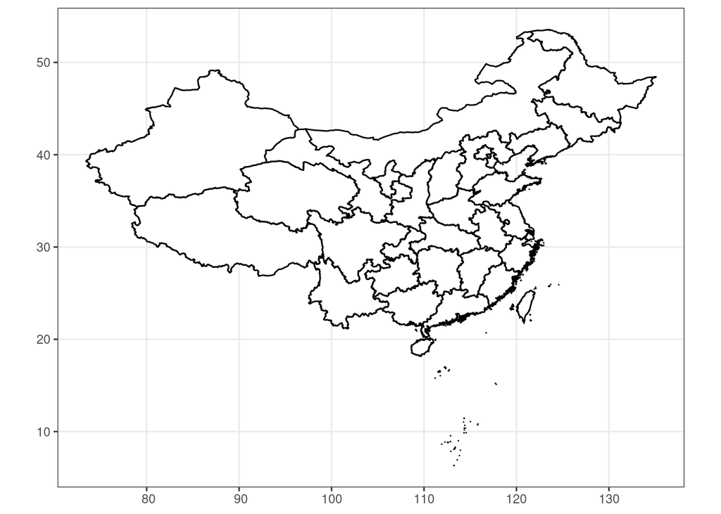

```r
chn_map %>%
  ggplot() +
  geom_sf(mapping = aes(geometry = geometry), color = "black", fill = "white") +
  #geom_sf_label(mapping = aes(label = NAME)) +
  theme_bw() # better for maps
```

These are the provinces available from the JHU sheets.

```r
ncov_tbl %>%
  filter(`Country/Region` %in% c("Mainland China", "Macau", "Hong Kong", "Taiwan")) %>%
  distinct(`Province/State`, `Country/Region`) %>%
  print(n = Inf)
```

```
## # A tibble: 34 x 2
##    `Province/State` `Country/Region`
##    <chr>            <chr>
##  1 Anhui            Mainland China
##  2 Beijing          Mainland China
##  3 Chongqing        Mainland China
##  4 Fujian           Mainland China
##  5 Gansu            Mainland China
##  6 Guangdong        Mainland China
##  7 Guangxi          Mainland China
##  8 Guizhou          Mainland China
##  9 Hainan           Mainland China
## 10 Hebei            Mainland China
## 11 Heilongjiang     Mainland China
## 12 Henan            Mainland China
```

[output cut: 22 more lines]

In order to join the tibbles `ncov_tbl` and `chn_map`, we need to use the province name as key. Let’s create a function to translate Chinese province name to English.

```r
translate <- function(x) {
  sapply(x, function(chn_name) {
    if (str_detect(chn_name, "澳门")) {
      eng_name <- "Macau"
    } else if (str_detect(chn_name, "台湾")) {
      eng_name <- "Taiwan"
    } else if (str_detect(chn_name, "上海")) {
      eng_name <- "Shanghai"
    } else if (str_detect(chn_name, "云南")) {
      eng_name <- "Yunnan"
    } else if (str_detect(chn_name, "内蒙古")) {
      eng_name <- "Inner Mongolia"
    } else if (str_detect(chn_name, "北京")) {
      eng_name <- "Beijing"
    } else if (str_detect(chn_name, "台湾")) {
      eng_name <- "Taiwan"
    } else if (str_detect(chn_name, "吉林")) {
      eng_name <- "Jilin"
    } else if (str_detect(chn_name, "四川")) {
      eng_name <- "Sichuan"
    } else if (str_detect(chn_name, "天津")) {
      eng_name <- "Tianjin"
    } else if (str_detect(chn_name, "宁夏")) {
      eng_name <- "Ningxia"
    } else if (str_detect(chn_name, "安徽")) {
      eng_name <- "Anhui"
    } else if (str_detect(chn_name, "山东")) {
      eng_name <- "Shandong"
    } else if (str_detect(chn_name, "山西")) {
      eng_name <- "Shanxi"
    } else if (str_detect(chn_name, "广东")) {
      eng_name <- "Guangdong"
    } else if (str_detect(chn_name, "广西")) {
      eng_name <- "Guangxi"
    } else if (str_detect(chn_name, "新疆")) {
      eng_name <- "Xinjiang"
    } else if (str_detect(chn_name, "江苏")) {
      eng_name <- "Jiangsu"
    } else if (str_detect(chn_name, "江西")) {
      eng_name <- "Jiangxi"
    } else if (str_detect(chn_name, "河北")) {
      eng_name <- "Hebei"
    } else if (str_detect(chn_name, "河南")) {
      eng_name <- "Henan"
    } else if (str_detect(chn_name, "浙江")) {
      eng_name <- "Zhejiang"
    } else if (str_detect(chn_name, "海南")) {
      eng_name <- "Hainan"
    } else if (str_detect(chn_name, "湖北")) {
      eng_name <- "Hubei"
    } else if (str_detect(chn_name, "湖南")) {
      eng_name <- "Hunan"
    } else if (str_detect(chn_name, "甘肃")) {
      eng_name <- "Gansu"
    } else if (str_detect(chn_name, "福建")) {
      eng_name <- "Fujian"
    } else if (str_detect(chn_name, "西藏")) {
      eng_name <- "Tibet"
    } else if (str_detect(chn_name, "贵州")) {
      eng_name <- "Guizhou"
    } else if (str_detect(chn_name, "辽宁")) {
      eng_name <- "Liaoning"
    } else if (str_detect(chn_name, "重庆")) {
      eng_name <- "Chongqing"
    } else if (str_detect(chn_name, "陕西")) {
      eng_name <- "Shanxi"
    } else if (str_detect(chn_name, "青海")) {
      eng_name <- "Qinghai"
    } else if (str_detect(chn_name, "香港")) {
      eng_name <- "Hong Kong"
    } else if (str_detect(chn_name, "黑龙江")) {
      eng_name <- "Heilongjiang"
    } else {
      eng_name <- chn_name # don't translate if no correspondence
    }
    return(eng_name)
  })
}
```

Create a new variable `NAME_ENG`:

```r
chn_prov <- chn_map %>%
  count(NAME) %>%
  mutate(NAME_ENG = translate(NAME)) # translate function is vectorized
chn_prov %>% print(n = Inf)
```

```
## Simple feature collection with 34 features and 3 fields
## geometry type:  GEOMETRY
## dimension:      XY
## bbox:           xmin: 73.44696 ymin: 6.318641 xmax: 135.0858 ymax: 53.55793
## epsg (SRID):    NA
## proj4string:    NA
## # A tibble: 34 x 4
##    NAME           n                                          geometry NAME_ENG
##  * <chr>      <int>                                        <GEOMETRY> <chr>
##  1 上海市        12 MULTIPOLYGON (((121.414 30.6952, 121.415 30.6975… Shanghai
##  2 云南省         1 POLYGON ((98.65588 28.83075, 98.65788 28.8333, 9… Yunnan
##  3 内蒙古自治区…     1 POLYGON ((121.4884 53.33265, 121.4974 53.32104, … Inner Mon…
##  4 北京市         1 POLYGON ((117.496 40.66534, 117.4992 40.64039, 1… Beijing
##  5 台湾省        57 MULTIPOLYGON (((120.8155 21.75681, 120.8174 21.7… Taiwan
##  6 吉林省         1 POLYGON ((123.171 46.24668, 123.2186 46.26945, 1… Jilin
```

[output cut: 28 more lines]

## Plotting 2019-nCoV incidence

Try to join the virus data `ncov_tbl` and map data `chn_prov`.

```r
# for exploration
plotdate <- "2020-02-14"
case <- "confirmed"
ncov_tbl %>%
  filter(`Country/Region` %in% c("Mainland China", "Macau", "Hong Kong", "Taiwan")) %>%
  filter(Date == plotdate, Case == case) %>%
  group_by(`Province/State`) %>%
  top_n(1, Date) %>%
  right_join(chn_prov, by = c("Province/State" = "NAME_ENG")) # join map and virus data
```

```
## # A tibble: 34 x 10
## # Groups:   Province/State [33]
##    `Province/State` `Country/Region`   Lat  Long Date       Case  Count NAME
##    <chr>            <chr>            <dbl> <dbl> <date>     <chr> <dbl> <chr>
##  1 Shanghai         Mainland China    31.2  121. 2020-02-14 conf…   318 上海市…
##  2 Yunnan           Mainland China    25.0  101. 2020-02-14 conf…   162 云南省…
##  3 Inner Mongolia   Mainland China    44.1  114. 2020-02-14 conf…    65 内蒙古自…
##  4 Beijing          Mainland China    40.2  116. 2020-02-14 conf…   372 北京市…
##  5 Taiwan           Taiwan            23.7  121. 2020-02-14 conf…    18 台湾省…
##  6 Jilin            Mainland China    43.7  126. 2020-02-14 conf…    86 吉林省…
##  7 Sichuan          Mainland China    30.6  103. 2020-02-14 conf…   463 四川省…
##  8 Tianjin          Mainland China    39.3  117. 2020-02-14 conf…   120 天津市…
##  9 Ningxia          Mainland China    37.3  106. 2020-02-14 conf…    67 宁夏回族…
## 10 Anhui            Mainland China    31.8  117. 2020-02-14 conf…   934 安徽省…
## # … with 24 more rows, and 2 more variables: n <int>, geometry <GEOMETRY>
```

Plot confirmed cases on a specific date:

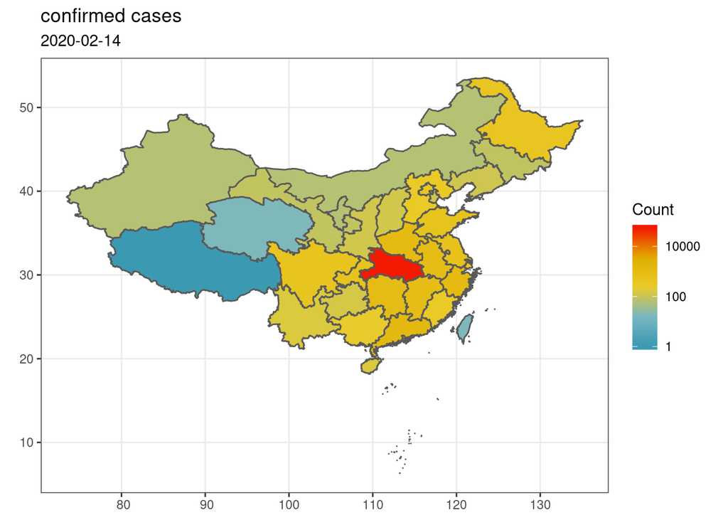

```r
library(wesanderson)

plotdate <- "2020-02-14"
case <- "confirmed"

ncov_tbl %>%
  filter(`Country/Region` %in% c("Mainland China", "Macau", "Hong Kong", "Taiwan")) %>%
  filter(Date == plotdate, Case == case) %>%
  group_by(`Province/State`) %>%
  top_n(1, Date) %>% # take the latest count on that date
  right_join(chn_prov, by = c("Province/State" = "NAME_ENG")) %>%
  ggplot() +
  geom_sf(mapping = aes(fill = Count, geometry = geometry)) +
  # scale_fill_gradient(low = "white",
  #                     high = "red",
  #                     trans = "log10",
  #                     limits = c(1, 50000),
  #                     breaks = c(1, 10, 100, 1000, 10000),
  #                     name = "") +
  scale_fill_gradientn(colors = wes_palette("Zissou1", 100, type = "continuous"),
                       trans = "log10") + # can we find a better palette?
  # #scale_fill_brewer(palette = "Dark2") +
  theme_bw() +
  labs(title = str_c(case, " cases"), subtitle = plotdate)
```

To plot the line graph of confirmed cases over time. You can do an animization of this over time.

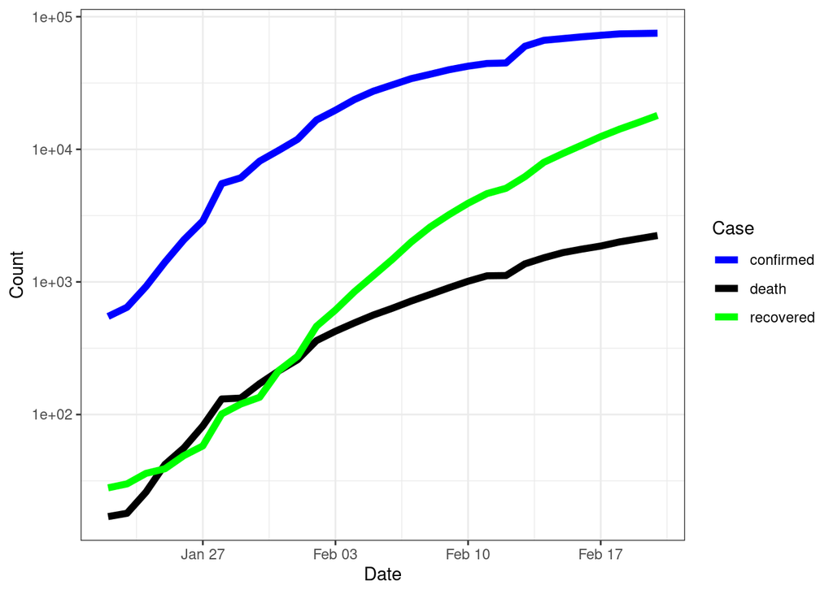

```r
ncov_tbl %>%
  filter(`Country/Region` %in% c("Mainland China", "Macau", "Hong Kong", "Taiwan")) %>%
  group_by(Date, Case) %>%
  summarise(total_count = sum(Count)) %>%
  # print()
  ggplot() +
  geom_line(mapping = aes(x = Date, y = total_count, color = Case), size = 2) +
  scale_color_manual(values = c("blue", "black", "green")) +
  scale_y_log10() +
  labs(y = "Count") +
  theme_bw()
```

Counts by province on a specific date. Do an animation on date.

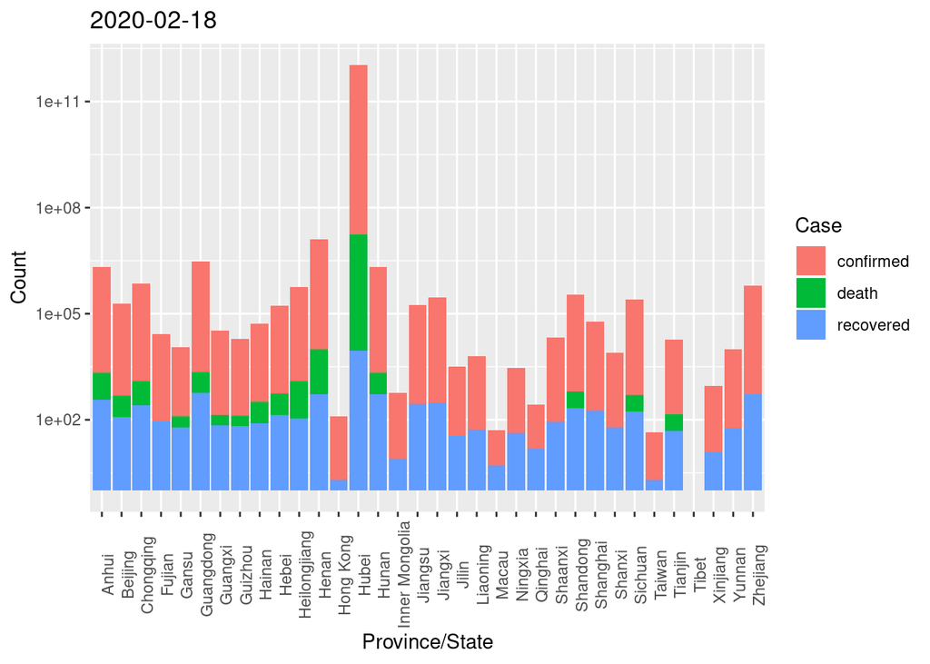

```r
date <- "2020-02-18"
ncov_tbl %>%
  filter(`Country/Region` %in% c("Mainland China", "Macau", "Hong Kong", "Taiwan"),
         `Date` == date) %>%
  group_by(`Province/State`) %>%
  ggplot() +
  geom_col(mapping = aes(x = `Province/State`, y = `Count`, fill = `Case`)) +
  scale_y_log10() +
  labs(title = date) +
  theme(axis.text.x = element_text(angle = 90))
```

## Animation

Resources about making animations in R:  
- [gganimate](https://gganimate.com/index.html) package.  
- Section 8.3 of [Geomcomputation with R](https://geocompr.robinlovelace.net/adv-map.html#animated-maps).

```r
ncov_tbl %>%
  filter(`Country/Region` %in% c("Mainland China", "Macau", "Hong Kong", "Taiwan")) %>%
  filter(Case == case) %>%
  right_join(chn_prov, by = c("Province/State" = "NAME_ENG")) %>%
  print()
```

```
## # A tibble: 1,020 x 10
##    `Province/State` `Country/Region`   Lat  Long Date       Case  Count NAME
##    <chr>            <chr>            <dbl> <dbl> <date>     <chr> <dbl> <chr>
##  1 Shanghai         Mainland China    31.2  121. 2020-01-22 conf…     9 上海市…
##  2 Shanghai         Mainland China    31.2  121. 2020-01-23 conf…    16 上海市…
##  3 Shanghai         Mainland China    31.2  121. 2020-01-24 conf…    20 上海市…
##  4 Shanghai         Mainland China    31.2  121. 2020-01-25 conf…    33 上海市…
##  5 Shanghai         Mainland China    31.2  121. 2020-01-26 conf…    40 上海市…
##  6 Shanghai         Mainland China    31.2  121. 2020-01-27 conf…    53 上海市…
##  7 Shanghai         Mainland China    31.2  121. 2020-01-28 conf…    66 上海市…
##  8 Shanghai         Mainland China    31.2  121. 2020-01-29 conf…    96 上海市…
##  9 Shanghai         Mainland China    31.2  121. 2020-01-30 conf…   112 上海市…
## 10 Shanghai         Mainland China    31.2  121. 2020-01-31 conf…   135 上海市…
## # … with 1,010 more rows, and 2 more variables: n <int>,
## #   geometry <MULTIPOLYGON>
```

Plot the date at all time points (this takes long, a couple minutes):

```r
library(gganimate)
library(transformr)

case = "confirmed"

(p <- ncov_tbl %>%
  filter(`Country/Region` %in% c("Mainland China", "Macau", "Hong Kong", "Taiwan")) %>%
  filter(Case == case) %>%
  right_join(chn_prov, by = c("Province/State" = "NAME_ENG")) %>%
  ggplot() +
  geom_sf(mapping = aes(fill = Count, geometry = geometry)) +
  # scale_fill_gradient(low = "white",
  #                     high = "red",
  #                     trans = "log10",
  #                     limits = c(1, 100000),
  #                     breaks = c(1, 10, 100, 1000, 10000),
  #                     name = "") +
  scale_fill_gradientn(colours = wes_palette("Zissou1", 100, type = "continuous"),
                       trans = "log10") +
  theme_bw() +
  labs(title = str_c(case, " cases")))
```

[output not shown]

Make animation and save as gif (this takes long, a couple minutes)

```r
(anim <- p +
  transition_time(Date) +
  labs(title = "Confirmed Cases", subtitle = "Date: {frame_time}"))
animate(anim, renderer = gifski_renderer())
anim_save("confirmed_anim.gif")
```

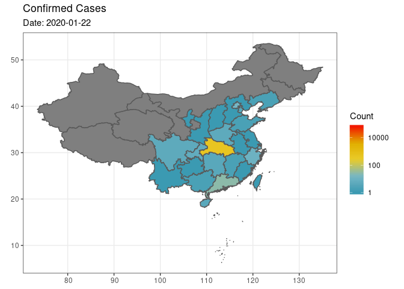

## Impact on economy

```r
library(quantmod)
```

```r
stock <- getSymbols("^HSI", # S&P 500 (^GSPC), Dow Jones (^DJI), NASDAQ (^IXIC), Russell 2000 (^RUT), FTSE 100 (^FTSE), Nikkei 225 (^N225), HANG SENG INDEX (^HSI)
                    src = "yahoo",
                    auto.assign = FALSE,
                    from = min(ncov_tbl$Date),
                    to = max(ncov_tbl$Date)) %>%
  as_tibble(rownames = "Date") %>%
  mutate(Date = date(Date)) %>%
  ggplot() +
  geom_line(mapping = aes(x = Date, y = HSI.Adjusted)) +
  theme_bw()
```

[output not shown]

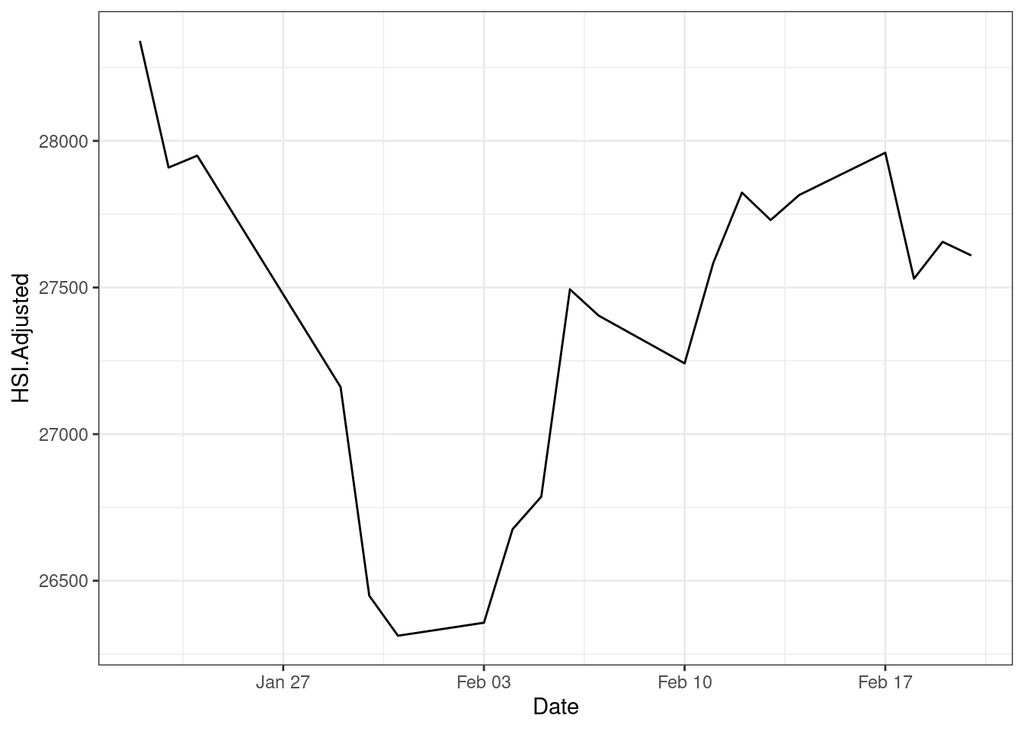

```r
stock
```

```r
# chartSeries(stock, theme = chartTheme("white"),
#            type = "line", log.scale = FALSE, TA = NULL)
```

## Mapping countries

TODO